# Practical Machine Learning - Course Project

Fernando Montenegro - fsmontenegro@gmail.com

10/25/2015

## Introduction

This report describes a practical exercise with machine learning given a real-world dataset coming from research associated with the “Quantified Self” movement. The original research was performed by the Informatics Department at PUC-RIO.

The background for the research is that a number of human subjects performed weightlifting exercises while wearing a number of sensors to track movement. The objective of the research project was to predict how well a particular exercise would be performed, given the multitude of sensor inputs. The possible outcomes were:

- Class A: correct, done according to the specification
- Class B: incorrect: elbows thrown to the front
- Class C: incorrect: dumbbell lifted only halfway
- Class D: incorrect: dumbbell lowered only halfway
- Class E: incorrect: hips thrown to the front.

More details, including the full academic paper, are available at [http://groupware.les.inf.puc-rio.br/har]. The exact reference for this research is:

> Ugulino, W.; Cardador, D.; Vega, K.; Velloso, E.; Milidiu, R.; Fuks, H. Wearable Computing: Accelerometers’ Data Classification of Body Postures and Movements. Proceedings of 21st Brazilian Symposium on Artificial Intelligence. Advances in Artificial Intelligence - SBIA 2012. In: Lecture Notes in Computer Science. , pp. 52-61. Curitiba, PR: Springer Berlin / Heidelberg, 2012. ISBN 978-3-642-34458-9. DOI: 10.1007/978-3-642-34459-6_6.

This report describes the data manipulation and application of machine learning concepts used to perform prediction on a test set.

As an aribtrary starting point, we chose to pursue an approach that would yield better than 95% accuracy against its test sets.

## Libraries, Data Loading and Manipulation

A number of libraries were used. In some cases, we chose to suppress messages to avoid cluttering in this report.

```r
library(ggplot2) ; library(lattice) ; library(caret) ; suppressMessages(library(rattle))
library(rpart) ; library(rpart.plot) ; library (scales) ; suppressMessages(library (randomForest))
```

Data is downloaded from the course pages, if needed.

```r
training_url <- "https://d396qusza40orc.cloudfront.net/predmachlearn/pml-training.csv"
testing_url <- "https://d396qusza40orc.cloudfront.net/predmachlearn/pml-testing.csv"

# download training dataset if it doesn't exist locally
if(!file.exists("./pml-training.csv")) {
  download.file(training_url,destfile = "./pml-training.csv", method = "curl")
}

# download testing dataset if it doesn't exist locally
if(!file.exists("./pml-testing.csv")) {
  download.file(testing_url,destfile = "./pml-testing.csv", method = "curl")
}

# load training set, with early coding of errors as NA
full_train <- read.csv("pml-training.csv", na.strings = c("NA", "#DIV/0!", ""))
```

### Remove NA’s and Additional Columns

The main steps in cleaning up this particular dataset were to:

1. remove NA, empty, and erroneous values (originally coded as ‘#DIV/0!’)
2. remove columns that were not measurements that could contribute to the target. These were found in columns 1-7 of the dataset: details about the subject, timestamp, and data collection.
3. remove co-variates: identify and remove columns that have co-variates that will not contribute to prediction.

```r
# Eliminate Columns with any NAs
t1 <- full_train[, colSums(is.na(full_train)) == 0]

# Check columns
names(t1)[1:7]
```

```
## [1] "X"                    "user_name"            "raw_timestamp_part_1"
## [4] "raw_timestamp_part_2" "cvtd_timestamp"       "new_window"
## [7] "num_window"
```

```r
# Remove unneeded columns
t1 <- t1[, -c(1:7)]

# Remove Co-variate columns, if any
cov_cols <- nearZeroVar(t1)

if (length(cov_cols)>0) {
  filtered_train <- t1[,-cov_cols]
} else {
  filtered_train <- t1
}

# Filtered Training set
dim(filtered_train)
```

```
## [1] 19622    53
```

The resulting dataset has 53 variables, including the target ‘classe’ factor.

### Data Splitting

The next steps were to perform Data Splitting on the training set, in order to support cross-validation of the predictions prior to full evaluation against the final test set. We chose to use a 60%/40% split.

```r
# Set random seed to support reproducibility
set.seed(42)

# Split the training set with a 60/40 train/test split
index_train <- createDataPartition(filtered_train$classe, p = 0.6, list = FALSE)
split_train <- filtered_train[index_train, ]
split_test <- filtered_train[-index_train, ]
dim(split_train)
```

```
## [1] 11776    53
```

```r
dim(split_test)
```

```
## [1] 7846   53
```

## Cross-Validation

The method chosen for cross-validation was k-fold, using k=5. This offers a good balance between performance, bias, and variance.

```r
# Create cross-validation control
cv_control <- trainControl(method = "cv", number = 5)
```

## Prediction Approach 1 - Classification Tree

The initial approach to prediction was to use a Classification Tree.

> NOTE: While performing this investigation, I used R’s ‘save’ and ‘load’ functions to save/load the results of the time-consuming model fit training operations. If necessary for full reproducibility, please comment out the “load” function and uncomment the “train” and optionally the “save” functions below.

```r
# Model Fit using CART
load(file="model-rpart")
# modelfit_rpart <- train(classe ~ ., data = split_train, method = "rpart", trControl = cv_control)
# save(modelfit_rpart,file = "model-rpart")

# Output in Numeric and Graphical form
print(modelfit_rpart, digits = 4)
```

```
## CART
##
## 11776 samples
##    52 predictor
##     5 classes: 'A', 'B', 'C', 'D', 'E'
##
## No pre-processing
## Resampling: Cross-Validated (5 fold)
## Summary of sample sizes: 9420, 9420, 9420, 9423, 9421
## Resampling results across tuning parameters:
##
##   cp       Accuracy  Kappa    Accuracy SD  Kappa SD
##   0.03287  0.5114    0.36249  0.00524      0.006657
##   0.06071  0.4702    0.29885  0.05894      0.098618
##   0.11497  0.3483    0.09746  0.03580      0.054508
##
## Accuracy was used to select the optimal model using  the largest value.
## The final value used for the model was cp = 0.03287.
```

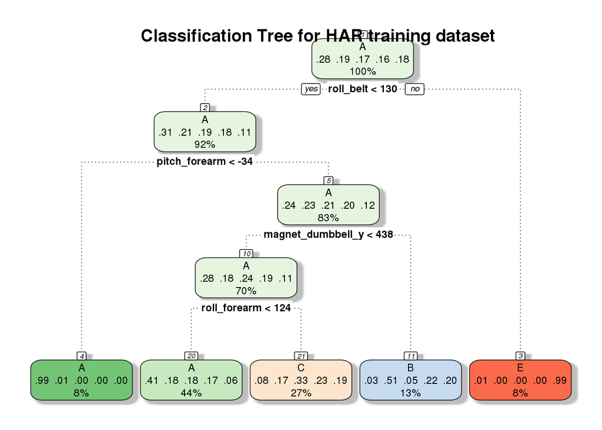

```r
fancyRpartPlot(modelfit_rpart$finalModel,main="Classification Tree for HAR training dataset",sub="")
```

```r
# Perform prediction against the test portion of the training data
prediction_rpart <- predict(modelfit_rpart,split_test)

# Evaluate prediction against known classification
confusion_rpart <- confusionMatrix(split_test$classe,prediction_rpart)
confusion_rpart
```

```
## Confusion Matrix and Statistics
##
##           Reference
## Prediction    A    B    C    D    E
##          A 2024   41  161    0    6
##          B  625  515  378    0    0
##          C  644   39  685    0    0
##          D  573  245  468    0    0
##          E  230  188  370    0  654
##
## Overall Statistics
##
##                Accuracy : 0.4943
##                  95% CI : (0.4831, 0.5054)
##     No Information Rate : 0.522
##     P-Value [Acc > NIR] : 1
##
##                   Kappa : 0.3388
##  Mcnemar's Test P-Value : NA
##
## Statistics by Class:
##
##                      Class: A Class: B Class: C Class: D Class: E
## Sensitivity            0.4941  0.50097  0.33220       NA  0.99091
## Specificity            0.9445  0.85289  0.88192   0.8361  0.89034
## Pos Pred Value         0.9068  0.33926  0.50073       NA  0.45354
## Neg Pred Value         0.6309  0.91893  0.78743       NA  0.99906
## Prevalence             0.5220  0.13102  0.26281   0.0000  0.08412
## Detection Rate         0.2580  0.06564  0.08731   0.0000  0.08335
## Detection Prevalence   0.2845  0.19347  0.17436   0.1639  0.18379
## Balanced Accuracy      0.7193  0.67693  0.60706       NA  0.94063
```

```r
# Obtain accuracy (used for estimating out of sample errors)
accuracy_rpart <- confusion_rpart$overall[[1]]
```

The overall accuracy for the Classification Tree approach was just 49.4%, meaning that the Out of Sample error expected for this approach is 50.6%.

Based on this result, which falls well below the original 95% accuracy goal, the conclusion is that the Classification Tree approach is *not* suitable, and a different method should be sought.

## Prediction Approach 2 - Random Forest

The Random Forest method fits a number of decision trees using subsamples of the dataset and then applies an averaging function to control for over-fitting and improve accuracy. Note that Random Forest does cross-validation internally, so there’s no need to specify the specific cross-validation parameters.

> NOTE: While performing this investigation, I used R’s ‘save’ and ‘load’ functions to save/load the results of the time-consuming model fit training operations. If necessary for full reproducibility, please comment out the “load” function and uncomment the “train” and optionally the “save” functions below.

```r
# Model Fit using Random Forest
load("model-rf")
#modelfit_rf <- train(classe ~ ., data = split_train, method = "rf")
#save(modelfit_rf,file = "model-rf")

# Output in Numeric form
print(modelfit_rf, digits = 4)
```

```
## Random Forest
##
## 11776 samples
##    52 predictor
##     5 classes: 'A', 'B', 'C', 'D', 'E'
##
## No pre-processing
## Resampling: Bootstrapped (25 reps)
## Summary of sample sizes: 11776, 11776, 11776, 11776, 11776, 11776, ...
## Resampling results across tuning parameters:
##
##   mtry  Accuracy  Kappa   Accuracy SD  Kappa SD
##    2    0.9866    0.9830  0.002309     0.002924
##   27    0.9868    0.9833  0.002537     0.003220
##   52    0.9753    0.9688  0.004930     0.006260
##
## Accuracy was used to select the optimal model using  the largest value.
## The final value used for the model was mtry = 27.
```

```r
# Perform prediction against the test portion of the training data
prediction_rf <- predict(modelfit_rf,split_test)

# Evaluate prediction against known classification
confusion_rf <- confusionMatrix(split_test$classe,prediction_rf)
confusion_rf
```

```
## Confusion Matrix and Statistics
##
##           Reference
## Prediction    A    B    C    D    E
##          A 2230    2    0    0    0
##          B   12 1506    0    0    0
##          C    0    7 1357    4    0
##          D    0    0   19 1266    1
##          E    0    0    0    9 1433
##
## Overall Statistics
##
##                Accuracy : 0.9931
##                  95% CI : (0.991, 0.9948)
##     No Information Rate : 0.2858
##     P-Value [Acc > NIR] : < 2.2e-16
##
##                   Kappa : 0.9913
##  Mcnemar's Test P-Value : NA
##
## Statistics by Class:
##
##                      Class: A Class: B Class: C Class: D Class: E
## Sensitivity            0.9946   0.9941   0.9862   0.9898   0.9993
## Specificity            0.9996   0.9981   0.9983   0.9970   0.9986
## Pos Pred Value         0.9991   0.9921   0.9920   0.9844   0.9938
## Neg Pred Value         0.9979   0.9986   0.9971   0.9980   0.9998
## Prevalence             0.2858   0.1931   0.1754   0.1630   0.1828
## Detection Rate         0.2842   0.1919   0.1730   0.1614   0.1826
## Detection Prevalence   0.2845   0.1935   0.1744   0.1639   0.1838
## Balanced Accuracy      0.9971   0.9961   0.9922   0.9934   0.9989
```

```r
# Obtain accuracy (used for estimating out of sample errors)
accuracy_rf <- confusion_rf$overall[[1]]
```

The accuracy for Random Forest was *significantly* better at 99.3%, leading to an Out of Sample error of just 0.688%.

Based on this approach, we choose to use the Random Forest model to predict against the test data set.

## Prediction on Test Data

Given the Random Forest model chosen, we then loaded the ‘official’ test data and performed predictions against it.

```r
# load testing set, with early coding of errors as NA
final_test <- read.csv("pml-testing.csv", na.strings = c("NA", "#DIV/0!", ""))

# Perform prediction against the Random Forest model
final_prediction <- predict(modelfit_rf,final_test)

# Final prediction
final_prediction
```

```
##  [1] B A B A A E D B A A B C B A E E A B B B
## Levels: A B C D E
```

Please note: while not displayed in this report, the submission above scored 20/20 on the Course Project Submission page. Please contact the author if you require additional information/confirmation.

## Appendix - Coursera Submission Code

The course project also required that the prediction be submitted for evaluation. The code below created the separate submission files required for that. Please refer to the Course Project instructions for more details.

```r
pml_write_files = function(x){
  n = length(x)
  for(i in 1:n){
    filename = paste0("problem_id_",i,".txt")
    write.table(x[i],file=filename,quote=FALSE,row.names=FALSE,col.names=FALSE)
  }
}
pml_write_files(final_prediction)
```